# Final_Project

Xiaohe Ye

2022-12-05

## Introduction

The purpose of this project is to generate a model that will predict the return rate is positive or negative for ETH based on the activity of Twitter.

### Background

As Cryptocurreny popularized, it came as a big roar in social media. Cryptocurrency is A cryptocurrency is a digital or virtual currency that is secured by cryptography, which makes it nearly impossible to counterfeit or double-spend. More about the definition can be read on this website.

https://www.investopedia.eom/terms/c/cryptocurrency.asp

Once Cryptocurrencies hit the market, it created an uproar amongst the crowd. Many researchers claim that the fluctuation of emotions regarding cryptocurrencies by the public plays a significant part in the price fluctuations of the cryptocurrencies. The data was collected using the social media platform Twitter, and 181 altcoins were used combined in 426520 tweets over a period of 71 days. By using sentiment analysis, the VADER scores were collected and used in the dataset. To closely examine whether the prices of cryptocurrencies are really affected by sentiments of social media and cryptocurrency enthusiasts that display vivid emotion online, this dataset will be used to examine the relationship between the rate fluctuation and VADER score, as well as other factors that may show significant change in the price of the cryptocurrency.

#### What is Cryptocurrency?

Cryptocurrency is a digital currency designed to work as a medium of exchange through a computer network that is not reliant on any central authority, such as a government or bank, to uphold or maintain it. It is a decentralized system for verifying that the parties to a transaction have the money they claim to have, eliminating the need for traditional intermediaries, such as banks, when funds are being transferred between two entities.

https://en.wikipedia.org/wiki/Cryptocurrency

#### What is altcoin?

Every alternative to Bitcoin as an altcoin here.

#### what is Ethereum(ETH)?

Ethereum is a decentralized, open-source blockchain with smart contract functionality. Ether is the native cryptocurrency of the platform. Among cryptocurrencies, ether is second only to Bitcoin in market capitalization. In other words, Ethereum is the biggest altcoin according to its market capitalization.

https://en.wikipedia.org/wiki/Ethereum

#### VADER score

[figure not shown]

Fig 1. Visualization of VADER scores for two artificially generated example tweets.

https://journals.plos.org/plosone/article?id=10.1371/journal.pone.0208119#pone.0208119.s001

#### Dataset

- `Time`: (string) timestamp of query, unit is a calendar year. Both, rate(price) and social media activities were updated every $3$ hours.
- `Cryptocurrency`: (string) altcoin name
- `Rate`: (numeric) rate or price of certain altcoin, unit is one BTC
- `Volume`: (numeric) trading Volume
- `NumTweets`: (numeric) mean number of tweets, unit is Count(n)
- `Coumpound`: (numeric) mean VADER Score
- `Negative`: (numeric) mean negative VADER Score
- `Positive`: (numeric) mean positive VADER Score
- `Neutral`: (numeric) mean neutral VADER Score

### Loading and Exploring Raw Data

- Reading the dataset from a csv file into data frame.

```r
# loading data
crypto <- read_csv('compound.csv')
crypto <- select(crypto, columns = -1)
```

- These are the first $6$ rows of the dataset.

```r
# First 6 rows of the dataset with all columns
head(crypto)
```

```
## # A tibble: 6 × 9
##   Time                Cryptocu…¹    Rate  Volume NumTw…² Posit…³ Negat…⁴ Compo…⁵
##   <dttm>              <chr>        <dbl>   <dbl>   <dbl>   <dbl>   <dbl>   <dbl>
## 1 2017-03-21 09:58:23 ADCN       2.93e-5 4.65e+0       0   0        0      0
## 2 2017-03-21 09:59:24 ADZ        1.58e-5 1.20e+0       0   0        0      0
## 3 2017-03-21 10:00:25 AEON Coin  1.75e-4 1.36e+1       1   0        0.24  -0.625
## 4 2017-03-21 10:01:26 AGRS       8.84e-5 3.15e-1       0   0        0      0
## 5 2017-03-21 10:02:33 AMBER      3.9 e-6 4.90e-3       0   0        0      0
## 6 2017-03-21 10:03:34 AMP        8.12e-5 5.91e+2       5   0.293    0      0.622
## # … with 1 more variable: Neutral <dbl>, and abbreviated variable names
## #   ¹Cryptocurrency, ²NumTweets, ³Positive, ⁴Negative, ⁵Compound
```

```r
# size of the dataset
dim(crypto)
```

```
## [1] 94663     9
```

```r
length(unique(crypto$Cryptocurrency))
```

```
## [1] 181
```

- There is no missing value inside this dataset.

```r
# identify amount of missing value
sum(is.na(crypto))
```

```
## [1] 0
```

- Summaries the interested variables `Rate`, `Volume`, `NumTweets`, `Positive` `Negative`, `Compound`, `Neutral`.

```r
# Variable summaries
summary(crypto %>% select(-Time, -Cryptocurrency,))
```

```
##       Rate               Volume            NumTweets          Positive
##  Min.   :0.0000000   Min.   :     0.00   Min.   :  0.000   Min.   :0.00000
##  1st Qu.:0.0000066   1st Qu.:     1.34   1st Qu.:  0.000   1st Qu.:0.00000
##  Median :0.0000402   Median :    17.86   Median :  0.000   Median :0.00000
##  Mean   :0.0051729   Mean   :   806.20   Mean   :  4.506   Mean   :0.03376
##  3rd Qu.:0.0002806   3rd Qu.:   163.71   3rd Qu.:  2.000   3rd Qu.:0.03925
##  Max.   :1.1850000   Max.   :123413.15   Max.   :100.000   Max.   :0.73000
##     Negative           Compound           Neutral
##  Min.   :0.000000   Min.   :-0.92170   Min.   :0.0000
##  1st Qu.:0.000000   1st Qu.: 0.00000   1st Qu.:0.0000
##  Median :0.000000   Median : 0.00000   Median :0.0000
##  Mean   :0.008061   Mean   : 0.06097   Mean   :0.3692
##  3rd Qu.:0.000000   3rd Qu.: 0.03283   3rd Qu.:0.8856
##  Max.   :0.727000   Max.   : 0.95570   Max.   :1.0000
```

```r
crypto[, 3:9] %>% colMeans()
```

```
##         Rate       Volume    NumTweets     Positive     Negative     Compound
## 5.172925e-03 8.062020e+02 4.505667e+00 3.376317e-02 8.060791e-03 6.097376e-02
##      Neutral
## 3.691919e-01
```

## Data Cleaning

- Clean names: make the first letter of all column names lower letter, also add underscore between words in each column name.
- Filt out the rows with name `ETH` in column `cryptocurrency`. This altcoin is what we’re interested and all analyses will be based on.
- Parse date and add new columns: `date`, `month`, `day`
- Sort all the rows from earliest time to latest time.
- And we have $523$ observations and $12$ columns after cleaning and mining now.

```r
# clean names
crypto <- crypto %>% clean_names()

# Filt out the rows with name `ETH` in column `cryptocurrency`
crypto <- crypto %>% filter(cryptocurrency == "ETH")

# Parse date
crypto <- crypto %>%
  mutate(
    # create date into lubridate format
    date = parse_date(gsub( " .*$", "", crypto$time), "%Y-%m-%d"),#parse_date(time, "%d/%m/%Y")
    month = month(date),
    day = day(date),
    #timelag =
  )

# Sort by time, earliest -> latest
crypto <- crypto[order(crypto$time),]

head(crypto)
```

```
## # A tibble: 6 × 12
##   time                cryptocur…¹   rate volume num_t…² posit…³ negat…⁴ compound
##   <dttm>              <chr>        <dbl>  <dbl>   <dbl>   <dbl>   <dbl>    <dbl>
## 1 2017-03-21 10:55:49 ETH         0.0394 39255.      67  0.0643 0.00979  0.150
## 2 2017-03-21 14:07:51 ETH         0.0398 37324.      86  0.0250 0.0240  -0.00567
## 3 2017-03-21 17:19:23 ETH         0.0398 33729.      66  0.0567 0.0224   0.0402
## 4 2017-03-21 20:30:43 ETH         0.0379 32379.      69  0.0515 0.00891  0.0962
## 5 2017-03-21 23:42:44 ETH         0.0385 30799.      93  0.0435 0.021    0.0572
## 6 2017-03-22 02:54:35 ETH         0.0383 28007.      82  0.0369 0.0122   0.0881
## # … with 4 more variables: neutral <dbl>, date <date>, month <dbl>, day <int>,
## #   and abbreviated variable names ¹cryptocurrency, ²num_tweets, ³positive,
## #   ⁴negative
```

```r
dim(crypto)
```

```
## [1] 523  12
```

### Data Split

Both, prices and social media activities were updated every three hours to also allow for short-term analysis. These datasets are not continuous but split into two time periods. The first period starts on March 21 and ends on May 5, 2017 and thus covers 45 days. The data collected in this range represented the training set. The second period covers 26 days and starts on May 9 and ends on June 4, 2017. The data obtained in this range functioned as the test set. This set was used to evaluate the models based on the training set.

- Add a new column ‘return’, the computations are completed by
  $$return_1 = price_1 - price_0$$
  . This process has to be completed after data spliting. Since the time is continuous inside each dataset, but not between train dataset and test test. After the computation, I removed the $1st$ row of both datasets. Because of the logic of computation, the value of `return` of the $1st$ row is $0$, which is not true and may affect our future analysing result. Therefore, I think it’s a better idea to remove it here.
- Then I add new column `make_money`, this column is a factor and only contains value either ‘yes’ or ‘no’. And the values determined by whether the `return` is positive. If it’s positively, that means we make money! And this attribute is also our reponse variable, or what I’ll predict all the time in the whole report.
- Finally, I have $332$ samples for train dataset and $189$ samples for test dataset.
- Next, use *v*-fold cross-validation on the training set. Use 5 folds. Dataset is split into a 5 number of folds and is used to evaluate the model’s ability when given new data. K5 refers to the number of groups the data sample is split into. In other words we split the data points into 5 equally sized subsets in K-folds cross-validation, called “folds.” One split subsets act as the testing set, and the remaining folds will train the model.

```r
crypto_train <- crypto[which(crypto$date <= '2017-05-05'),] # data collected before '2017-05-05' were collecting for training, there are around 333 observations
crypto_test <- crypto[which(crypto$date >= '2017-05-09'),] # data collected before '2017-05-05' were collecting for testing, there are around 190 observations
#nrow(crypto)

#######claculate the return
crypto_train$new <- c(tail(crypto_train$rate, -1), 0) # add the `rate` of next row to current row as the value of `new`, make the last value of `new` column 0. Use tail() for extracting all values except the 1st one, b/c it's invalid.
crypto_train$return <- c(0,head((crypto_train$new - crypto_train$rate), -1)) # get the `return` by find out the difference between `new` and `rate`, which also means (price_1 - price_2), and also set the first value of `return` is 0. Use head() to keep all values except the last one, b/c it's invalid value
crypto_train <- tail(crypto_train, -1) # remove the first row, because the return rate is 0 there

crypto_test$new <- c(tail(crypto_test$rate, -1), 0) # did same thing, but it's for the test dataset
crypto_test$return <- c(
  0,head((crypto_test$new - crypto_test$rate), -1)) # did the same thing, but it's for the test dataset
crypto_test <- tail(crypto_test, -1) # remove the first row, because the return rate is 0 there

########Determine whether make money based on whether the value of `return` is positive.
crypto_train$make_money <- crypto_train$return > 0
crypto_train$make_money <-replace(
  crypto_train$make_money, crypto_train$make_money=='TRUE', 'yes')
crypto_train$make_money <- replace(
  crypto_train$make_money, crypto_train$make_money=='FALSE', 'no')
crypto_train$make_money <- factor(crypto_train$make_money)

crypto_test$make_money <- crypto_test$return > 0
crypto_test$make_money <-replace(
  crypto_test$make_money, crypto_test$make_money=='TRUE', 'yes')
crypto_test$make_money <- replace(
  crypto_test$make_money, crypto_test$make_money=='FALSE', 'no')
crypto_test$make_money <- factor(crypto_test$make_money)

nrow(crypto_train)
```

```
## [1] 332
```

```r
nrow(crypto_test)
```

```
## [1] 189
```

```r
# use *v*-fold cross-validation on the training set. Use 5 folds.
crypto_fold <- vfold_cv(crypto_train, v = 5)
```

## EDA (Exploratory Data Analysis)

The entire exploratory data analysis will be based on the training set, which has $332$ observations. Each observation represents a record of the data of ETH, and activities on Twitter relates to ETH at the moment of every three hours gap. The activity was measured by the number of tweets that referred to a certain altcoin and the sentiment that they contained.

### Distribution of VADER score variables

Positive, negative, neutral VADER score should sum to $1$ for each observation. We could see from the boxplots below that most tweets have higher neutral VADER score. Then, positive VADER score occupies a little higher portions than negative VADER score relatively. We might think the moods of people on Twitter is medium optimistic.

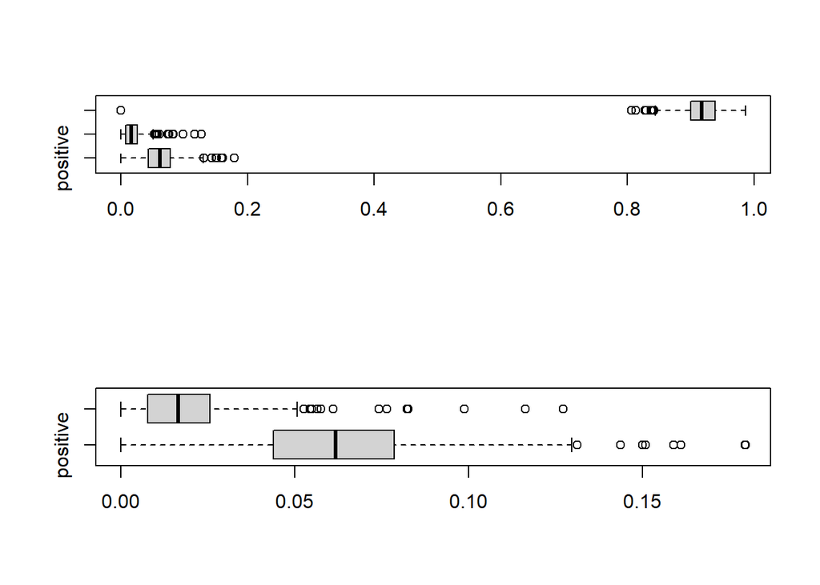

```r
par(mfrow=c(2,1))
boxplot(crypto_train[,c("positive","negative","neutral")], horizontal = TRUE)
boxplot(crypto_train[,c("positive","negative")], horizontal = TRUE)
```

### Variables

Let’s take a look how each attribute distributed. We coould see only compound and positive VADER score are approximately normal distributed.

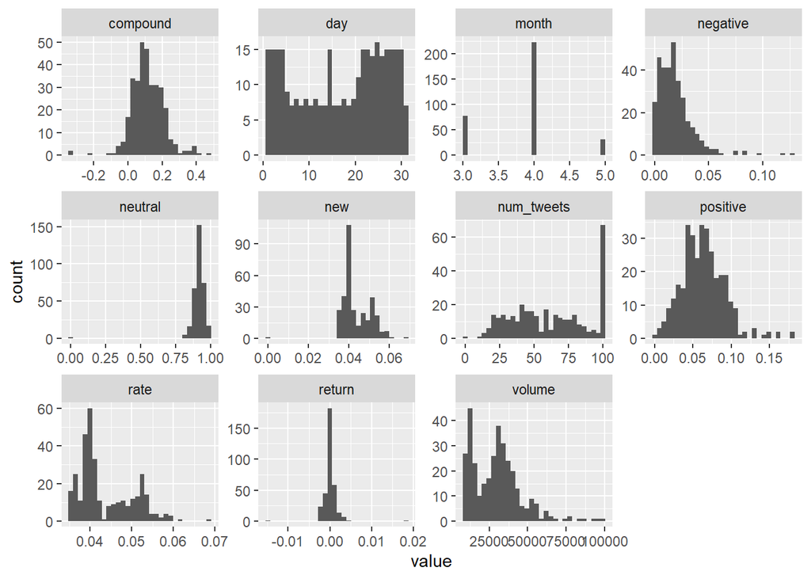

```r
crypto_train %>%
  keep(is.numeric) %>%
  gather() %>%
  ggplot(aes(value)) +
  facet_wrap(~ key, scales = 'free') +
  geom_histogram()
```

Let’s also take a look the how variables distributed numerically.

```r
summary(crypto_train)
```

```
##       time                        cryptocurrency          rate
##  Min.   :2017-03-21 14:07:51.07   Length:332         Min.   :0.03510
##  1st Qu.:2017-04-01 15:48:45.82   Class :character   1st Qu.:0.03911
##  Median :2017-04-12 17:30:41.21   Mode  :character   Median :0.04088
##  Mean   :2017-04-12 19:13:40.28                      Mean   :0.04376
##  3rd Qu.:2017-04-23 23:26:53.24                      3rd Qu.:0.04954
##  Max.   :2017-05-05 02:33:26.42                      Max.   :0.06819
##      volume        num_tweets        positive          negative
##  Min.   : 7792   Min.   :  0.00   Min.   :0.00000   Min.   :0.000000
##  1st Qu.:15461   1st Qu.: 38.00   1st Qu.:0.04391   1st Qu.:0.007797
##  Median :29855   Median : 59.00   Median :0.06172   Median :0.016435
##  Mean   :29797   Mean   : 61.38   Mean   :0.06326   Mean   :0.019409
##  3rd Qu.:37340   3rd Qu.: 85.00   3rd Qu.:0.07849   3rd Qu.:0.025609
##  Max.   :97574   Max.   :100.00   Max.   :0.17958   Max.   :0.127190
##     compound           neutral            date                month
##  Min.   :-0.33753   Min.   :0.0000   Min.   :2017-03-21   Min.   :3.000
##  1st Qu.: 0.05796   1st Qu.:0.8998   1st Qu.:2017-04-01   1st Qu.:4.000
##  Median : 0.10785   Median :0.9175   Median :2017-04-12   Median :4.000
##  Mean   : 0.11473   Mean   :0.9143   Mean   :2017-04-12   Mean   :3.858
##  3rd Qu.: 0.17226   3rd Qu.:0.9380   3rd Qu.:2017-04-23   3rd Qu.:4.000
##  Max.   : 0.46780   Max.   :0.9863   Max.   :2017-05-05   Max.   :5.000
##       day             new              return           make_money
##  Min.   : 1.00   Min.   :0.00000   Min.   :-1.470e-02   no :163
##  1st Qu.: 7.00   1st Qu.:0.03911   1st Qu.:-4.497e-04   yes:169
##  Median :19.00   Median :0.04088   Median : 2.051e-05
##  Mean   :16.78   Mean   :0.04364   Mean   : 6.583e-05
##  3rd Qu.:25.00   3rd Qu.:0.04954   3rd Qu.: 5.557e-04
##  Max.   :31.00   Max.   :0.06819   Max.   : 1.839e-02
```

And also check the mean values of each numerical variables.

```r
crypto_train[, 3:9] %>% colMeans()
```

```
##         rate       volume   num_tweets     positive     negative     compound
## 4.375859e-02 2.979741e+04 6.137952e+01 6.326480e-02 1.940901e-02 1.147291e-01
##      neutral
## 9.143160e-01
```

We could from the Month Distrubtion. That there are most records on Apr, 2017 for altcoins.

### Correlation Matrix

Create a correlation matrix of the training set. We could find there is moderately negative correlation between `compound` and `negative`. And there is highly positive correlation between `compound` and `positive`. This is not surprising according the way that caculate compound VADER score. However, we’ll still add interactions in the recepi later.

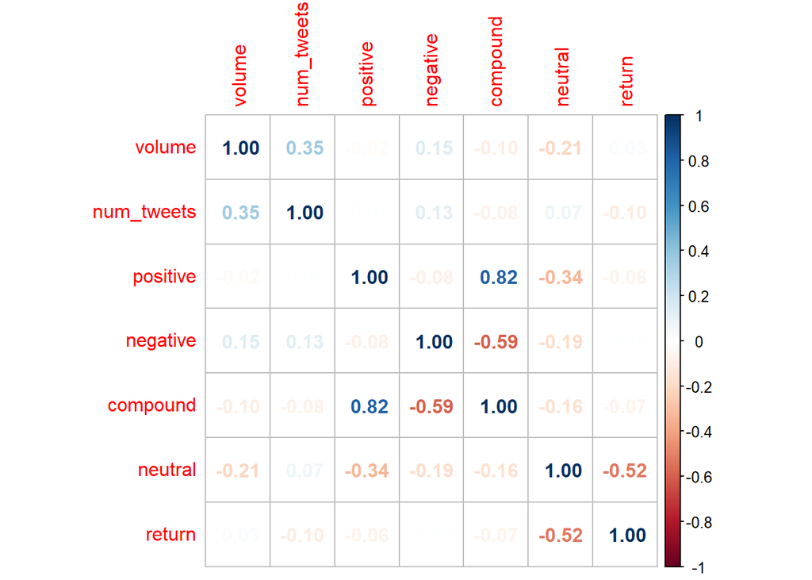

```r
library(corrplot)

crypto_train_new <- crypto_train %>% select(volume, num_tweets, positive, negative, compound, neutral, return)

crypto_corr = cor(crypto_train_new)

corrplot(crypto_corr, method = 'number')
```

### Exploration of Response Variable

We want to predict whether `make_money` at this moment, and this will be determined by `return`. Let’s break down further by `month`. We could see from the plot below that, most of the time that return is around $0$.

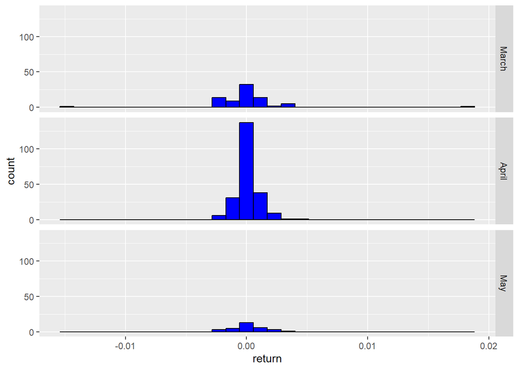

```r
graph <- crypto_train
graph$month <- as.factor(graph$month)
graph$month <- recode_factor(graph$month, '3' = 'March', '4' = 'April', '5' = 'May')
ggplot(graph, aes(x = return)) +
  geom_histogram(fill = "blue", colour = "black") +
  facet_grid(graph$month ~ .)
```

## Create Model

Firstly, we’ll create a recipe for all the models we’re going to make in next step. `make_money` would be the response variable, volume of trading, number of tweets, VADER scores(positive, negative, neutral, compound) are the predictors. Then we’ll add interactions between `compound` and `negatie`, `compound` and `positive`. Because they have correlations.

```r
# Set up a recipe to predict `make_money` with `volume`, `num_tweets`,
# `positive`, `negative`, `neutral`, `compound`
#update_role(everything(), new_role = "any role will do")
crypto_recipe <- recipe(make_money~volume+num_tweets+positive+negative+neutral+compound,
  data = crypto_train) %>%
  step_dummy(all_nominal_predictors()) %>%
  step_normalize(all_predictors()) %>%
  step_interact(terms = ~negative:compound) %>%
  step_interact(terms = ~positive:compound)
```

### Logistic Regression

- This is a classification model.
- Set up a workflow of logistic regression.
- Fit the $5$ folds of train data.
- Save results of model fitting into “logi_tune.rda”

```r
# Specifying an Engine
logi_model <- logistic_reg(penalty = 0) %>%
  set_engine("glm") %>%
  set_mode("classification")

# Workflow
logi_wf <- workflow() %>%
  add_recipe(crypto_recipe) %>%
  add_model(logi_model)

# Create grid
degree_grid <- grid_regular(degree(range = c(1, 5)), levels = 5)

# Fit model
logi_tune <- tune_grid(
  object = logi_wf,
  resamples = crypto_fold,
  grid = degree_grid
)

# Save data of model to a file. Then we don't need to run it again when knit.
save(logi_tune, logi_wf, file = "logi_tune.rda")
```

```r
show_best(logi_tune, metric = "roc_auc") %>% select(-.estimator, -.config)
```

```
## # A tibble: 1 × 4
##   .metric  mean     n std_err
##   <chr>   <dbl> <int>   <dbl>
## 1 roc_auc 0.535     5  0.0400
```

### Random Forest

- This is a classification model.
- Set up a workflow of random forest.
- Fit the $5$ folds of train data.
- Save results of model fitting into “rf_tune.rda”

```r
rf_model <-
  rand_forest(
              min_n = tune(),
              mtry = tune(),
              mode = "classification") %>%
  set_engine("ranger")

rf_workflow <- workflow() %>%
  add_model(rf_model) %>%
  add_recipe(crypto_recipe)

rf_params <- parameters(rf_model) %>%
  update(mtry = mtry(range= c(2, 6)))

# define grid
rf_grid <- grid_regular(rf_params, levels = 2)

rf_tune <- tune_grid(
  object = rf_workflow,
  resamples = crypto_fold,
  grid = rf_grid)

save(rf_tune, rf_workflow, file = "rf_tune.rda")
```

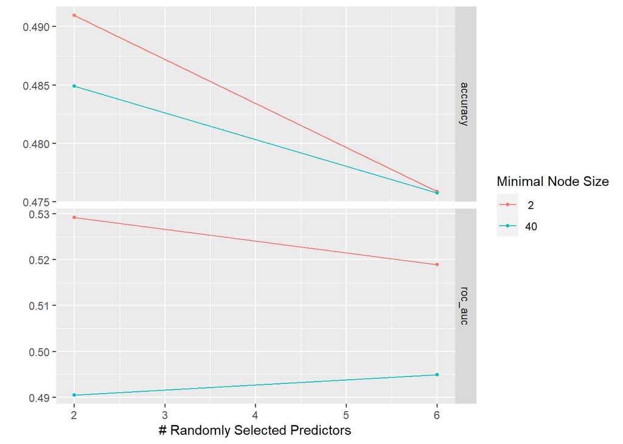

```r
autoplot(rf_tune)
```

```r
show_best(logi_tune, metric = "roc_auc") %>% select(-.estimator, -.config)
```

```
## # A tibble: 1 × 4
##   .metric  mean     n std_err
##   <chr>   <dbl> <int>   <dbl>
## 1 roc_auc 0.535     5  0.0400
```

```r
show_best(rf_tune, metric = "roc_auc") %>% select(-.estimator, -.config)
```

```
## # A tibble: 4 × 6
##    mtry min_n .metric  mean     n std_err
##   <int> <int> <chr>   <dbl> <int>   <dbl>
## 1     2     2 roc_auc 0.529     5  0.0527
## 2     6     2 roc_auc 0.519     5  0.0424
## 3     6    40 roc_auc 0.495     5  0.0428
## 4     2    40 roc_auc 0.490     5  0.0420
```

### Boosted Trees

- This is a classification model.
- Set up a workflow of boosted trees.
- Fit the $5$ folds of train data.
- Save results of model fitting into “bt_tune.rda”

```r
bt_model <- boost_tree(mode = "classification",
                       min_n = tune(),
                       mtry = tune(),
                       learn_rate = tune()) %>%
  set_engine("xgboost")

bt_workflow <- workflow() %>%
  add_model(bt_model) %>%
  add_recipe(crypto_recipe)

bt_params <- parameters(bt_model) %>%
  update(mtry = mtry(range= c(2, 6)),
         learn_rate = learn_rate(range = c(-5, 0.2))
  )

# define grid
bt_grid <- grid_regular(bt_params, levels = 2)

bt_tune <- bt_workflow %>%
  tune_grid(
    resamples = crypto_fold,
    grid = bt_grid
    )

save(bt_tune, bt_workflow, file = "bt_tune.rda")
```

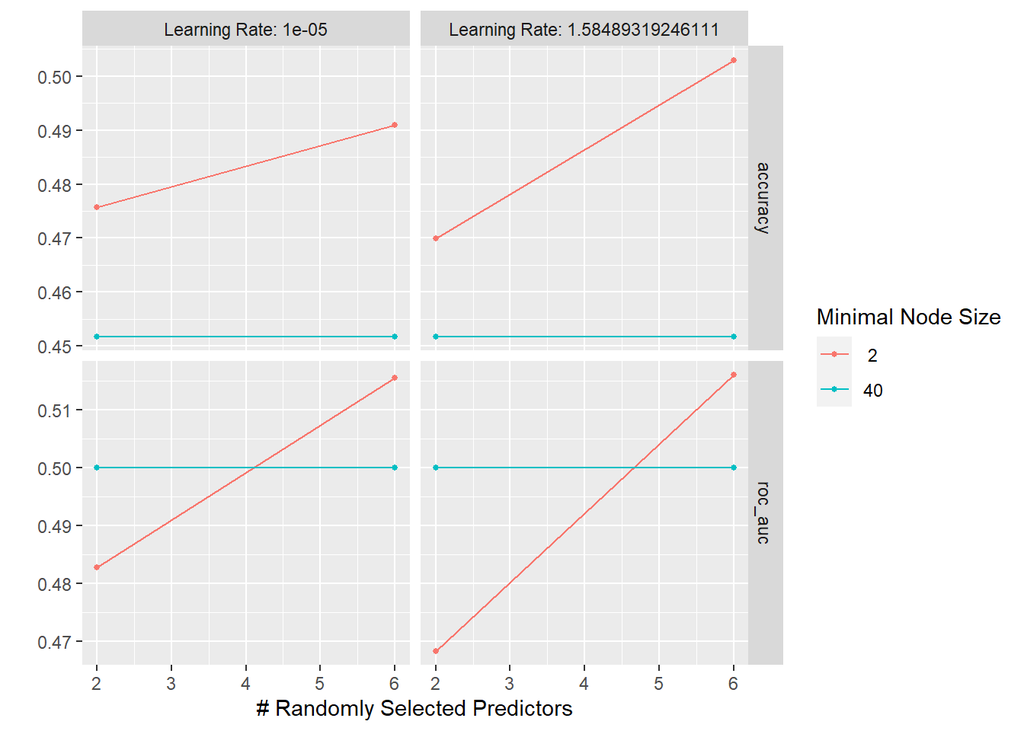

```r
autoplot(bt_tune)
```

```r
show_best(bt_tune, metric = "roc_auc") %>% select(-.estimator, -.config)
```

```
## # A tibble: 5 × 7
##    mtry min_n learn_rate .metric  mean     n std_err
##   <int> <int>      <dbl> <chr>   <dbl> <int>   <dbl>
## 1     6     2    1.58    roc_auc 0.516     5  0.0469
## 2     6     2    0.00001 roc_auc 0.515     5  0.0252
## 3     2    40    0.00001 roc_auc 0.5       5  0
## 4     6    40    0.00001 roc_auc 0.5       5  0
## 5     2    40    1.58    roc_auc 0.5       5  0
```

### KNN(K-nearest neighbors)

- This is a classification model.
- Set up a workflow of KNN.
- Fit the $5$ folds of train data.
- Save results of model fitting into “knn_tune.rda”

```r
knn_model <-
  nearest_neighbor(
    neighbors = tune(),
    mode = "classification") %>%
  set_engine("kknn")

knn_workflow <- workflow() %>%
  add_model(knn_model) %>%
  add_recipe(crypto_recipe)

# set-up tuning grid ----
knn_params <- parameters(knn_model)


# define grid
knn_grid <- grid_regular(knn_params, levels = 2)

knn_tune <- tune_grid(
  object = knn_workflow,
  resamples = crypto_fold,
  grid = knn_grid)

save(knn_tune, knn_workflow, file = "knn_tune.rda")
```

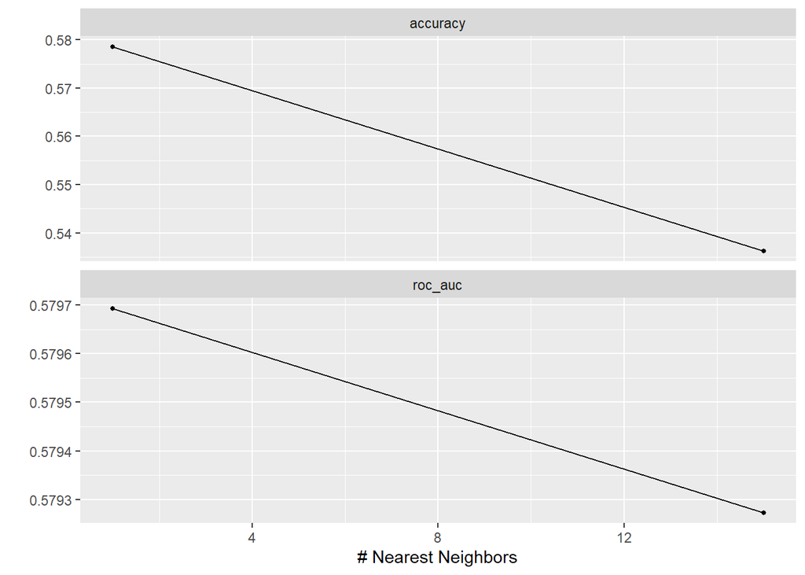

```r
autoplot(knn_tune)
```

Taking a quick peak at the autoplot() function, this shows that the idea number of neighbors is 1. Let’s confirm this with the show_best() function.

```r
show_best(knn_tune, metric = "roc_auc") %>% select(-.estimator, -.config)
```

```
## # A tibble: 2 × 5
##   neighbors .metric  mean     n std_err
##       <int> <chr>   <dbl> <int>   <dbl>
## 1         1 roc_auc 0.580     5  0.0354
## 2        15 roc_auc 0.579     5  0.0411
```

### Compare models

```r
# load the results of each model
load("logi_tune.rda")
load("bt_tune.rda")
load("rf_tune.rda")
load("knn_tune.rda")

# choose the best one of each of them.
#logi <- (show_best(logi_tune, metric = "roc_auc") %>% select(-.estimator, -.config))[1,]
#rf <- (show_best(rf_tune, metric = "roc_auc") %>% select(-.estimator, -.config))[1,]
#bt <- (show_best(bt_tune, metric = "roc_auc") %>% select(-.estimator, -.config))[1,]
#knn <- (show_best(knn_tune, metric = "roc_auc") %>% select(-.estimator, -.config))[1,]
logi <- (show_best(logi_tune, metric = "roc_auc") %>% select(mean))[1,]
rf <- (show_best(rf_tune, metric = "roc_auc") %>% select(mean))[1,]
bt <- (show_best(bt_tune, metric = "roc_auc") %>% select(mean))[1,]
knn <- (show_best(knn_tune, metric = "roc_auc") %>% select(mean))[1,]

table <- c(logi, rf, bt, knn)
table
```

```
## $mean
## [1] 0.5351904
##
## $mean
## [1] 0.5291632
##
## $mean
## [1] 0.5159845
##
## $mean
## [1] 0.5796933
```

## Final Fitting

```r
final_rf_workflow <- rf_workflow %>%
  finalize_workflow(select_best(rf_tune, metric = "roc_auc"))

rf_final_model <- fit(final_rf_workflow, crypto_train)

model_test_predictions <- predict(
  rf_final_model, new_data = crypto_test, type='class') %>%
  bind_cols(crypto_test %>% select(make_money))

model_test_predictions %>% accuracy(truth = make_money, estimate=.pred_class)
```

```
## # A tibble: 1 × 3
##   .metric  .estimator .estimate
##   <chr>    <chr>          <dbl>
## 1 accuracy binary         0.508
```

## Conclusion

Some ways that I may improve for this model. Firstly, the samples for ETH is not a lot. It might improve predicting if I could collect more relative datas in the future. Secondly, data were collected at a $3$ hours cycle due to the usage limitation of twitter api. But prices of cryptocurries are particularly volatile and it changes all the time. I could consier the way to collect data with a shorte time gap next time. Also we’re interested in whether social media activities affect the price of cryptocurries this time. So we take account the sentiment of messages. However, time might be also a factor to influence the sentiments or characteristics of tweets. I’ll take in account the time for improving model next time. Probably categorize the different time range.